# As partes em processos administrativos sancionadores

Renata Hirota

8/28/2020

# As partes em processos administrativos sancionadores

A análise de processos administrativos sancionadores passa pela caracterização das partes envolvidas nos casos. O tipo de parte e a forma de participação da parte, ou seja, a relação dela com a suposta infração, são algumas das características que podem definir como será o andamento do processo, uma vez que estratégias diferentes podem ser utilizadas para lidar com os casos a depender dos perfis. Neste artigo, apresentamos a metodologia de obtenção do tipo de parte para realizar as análises do projeto Observatório CVM.

## O que é o PAS?

Os processos administrativos sancionadores (PAS) são instaurados pela Comissão de Valores Mobiliários (CVM) e julgados pelo Colegiado da CVM. A CVM é uma autarquia vinculada ao Ministério da Economia que fiscaliza a atuação de agentes no mercado de valores mobiliário. Dentre algumas de suas responsabilidades, estão o registro de companhias abertas, a organização das bolsas de valores e o credenciamento de auditores independentes.

## Sobre os dados

Os dados foram obtidos por meio de quatro fontes: a consulta de processos (PAS), a consulta de processos julgados (PSJ), a consulta de termos de compromisso celebrados (TCC) e a base de atas do colegiado (ATAS). Após uma etapa de leitura manual dos autos, chegou-se a uma base final de 1235 processos distintos.

## Características das partes

Para a análise das partes, foram excluídas 88 observações de pessoas físicas que falecerem no curso do processo ou que tiveram como desfecho a extinção de punibilidade ou ilegitimidade passiva. De todas as 6.681 partes analisadas, **79%** eram pessoa física e 21% eram pessoa jurídica. Além disso, **48%** dos casos analisados envolvem tanto pessoas físicas quanto jurídicas.

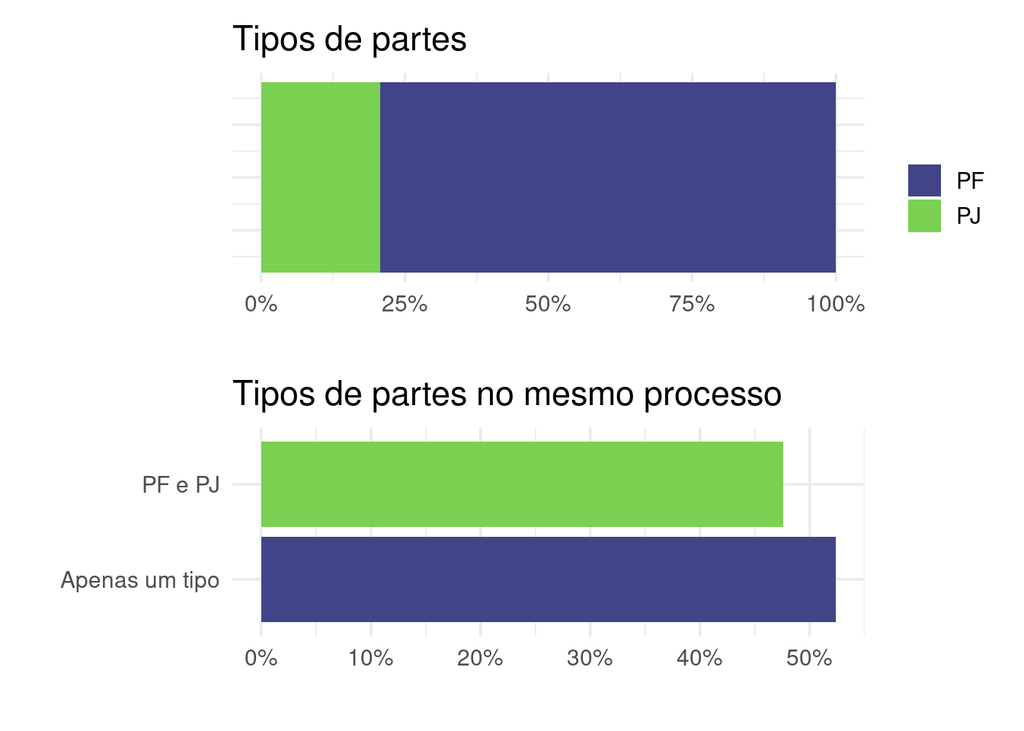

### Desfechos e características das partes

Embora não haja diferenças significativas entre pessoas físicas e pessoas jurídicas nos desfechos, notamos que algumas características como o setor de atuação, no caso de empresas, ou o tipo de participação, no caso de pessoas, estão associadas a determinados desfechos específicos.

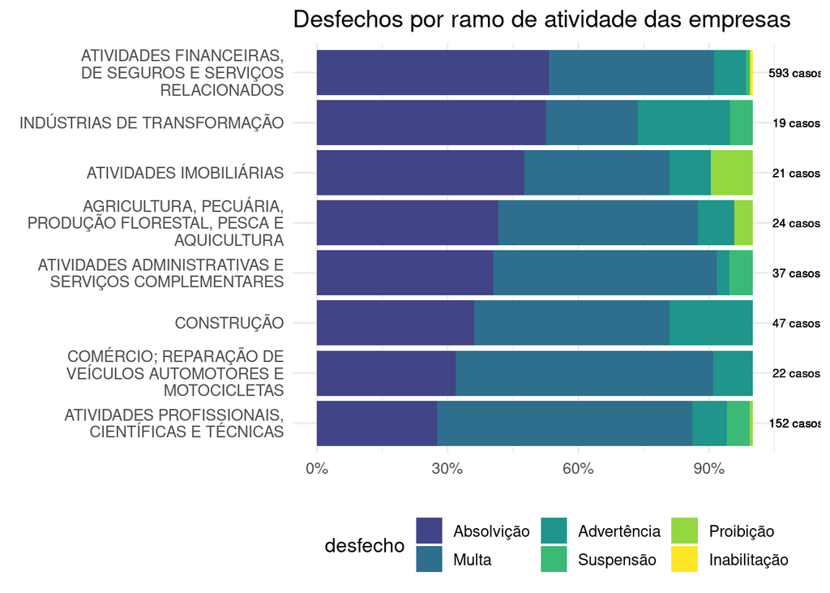

Nos casos em que as partes são pessoas jurídicas, a seção *Atividades financeiras, de seguros e serviços* associados está relacoinada a maiores taxas de absolvição, enquanto a seção *Atividades imobiliárias* está associada a maiores taxas de proibição.

Analisando a proporção de desfechos por forma de paticipação, por outro lado, é possível notar que Gerentes e Operadores estão associados a maiores taxas de absolvição, enquanto que o contrário ocorre com Auditores independentes e DRI, ou seja, estão associados a menores taxas de absolvição.

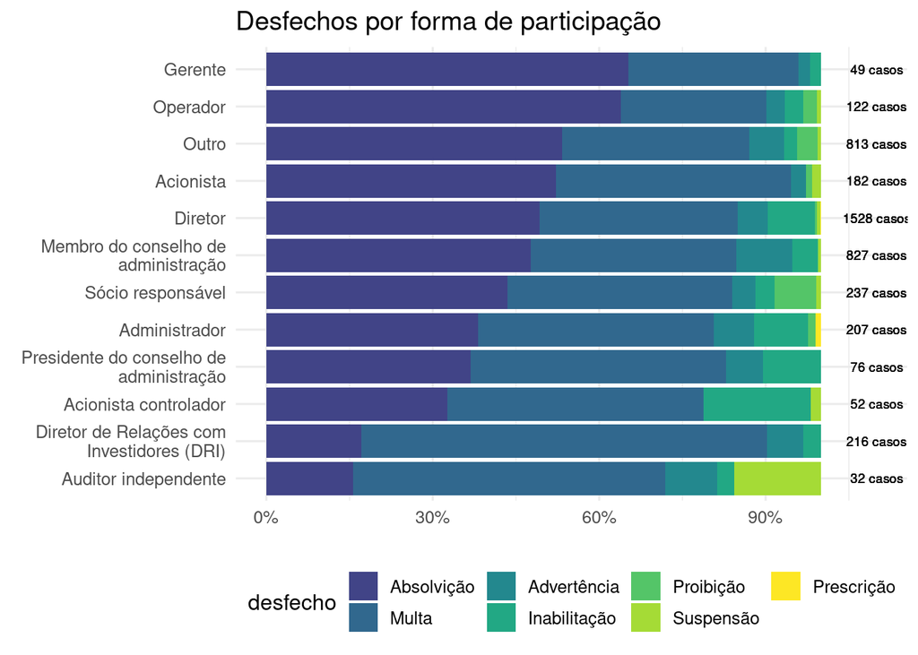